# Dear_Colleagues_project3

polly and co

2026-04-29

# Deliverables

> Team name: Dear Colleagues

> Names of all team members: Aleksandrova Polina, Berdnikova Yulia, Kistanova Daria, Kovalchuk Yulia, Kurlovich Anastasiia

> Description of each member’s contribution: Berdnikova and Kovalchuk worked on the first part, Aleksandrova, Kurlovich and Kistanova worked on the second part

> Topic and country: Italy, Predictors of Life Satisfaction

# Part I

> In this project we want to look at **the way life satisfaction is associated with household income and how this association is moderated by social and political trust in Italy**. Previous research (Clench-Aas & Holte, 2021) suggests that 2/3 of variance in the life satisfaction in European countries stem from income (personal, community and national). This association was significantly modified by trust, and all 3 forms of trust (personal, social, political) played the role of “buffer” moderating the relationship between life satisfaction and income. Findings showed that higher trust levels reduce the strength of relationship between income and life satisfaction. Thus, in high-trust contexts income matters less for individuals while in low-trust context, on the contrary, income is important and might strongly predict life satisfaction.

> For the sake of feasibility, we will not look at all the levels studied in the mentioned article. We decided to limit our analysis to three continuous predictors, namely trust in parliament (political trust), social trust and household income.

> The results of multilevel meta-analysis conducted by Bi et al.(2025) showed a positive overall association between trust and subjective well-being (relying on the article by Helliewell and Putnam (2004) we imply that “life satisfaction” is one of the measures of subjective well-being). It supports the expectation, that people who report higher levels of trust may also report higher life satisfaction. The authors noted that there were variations in the strength of association depending on the type of trust and other factors. Nevertheless, the results of longitudianl meta-analyses revealed that well-being predicts subsequent trust and vice versa.

> At the same time, Glatz and Schwerdtfeger (2022) show that the causal relationship between social trust, institutional trust and subjective well-being is complicated. Their findings suggest that well-being may also have an inmact on trust. Taking into account the previous research, the chosen variables can be considered theoretically justified predictors for life satisfaction.

> References: - Bi, S., Maes, M., Stevens, G. W. J. M., de Heer, C., Li, J.-B., Sun, Y., & Finkenauer, C. (2025). Trust and subjective well-being across the lifespan: A multilevel meta-analysis of cross-sectional and longitudinal associations. Psychological Bulletin, 151(6), 737-766. - Clench-Aas, J., & Holte, A. (2021). Political trust influences the relationship between income and life satisfaction in Europe: differential associations with trust at national, community, and individual level. Frontiers in public health, 9, 629118. - Helliwell, J. F., & Putnam, R. D. (2004). The social context of well–being. Philosophical Transactions of the Royal Society of London. Series B: Biological Sciences, 359(1449), 1435–1446. - Glatz, C., & Schwerdtfeger, A. (2022). Disentangling the causal structure between social trust, institutional trust, and subjective well-being. Social Indicators Research, 163, 1323–1348.

> **Hypothesis 1:** Household income and life satisfaction are positively correlated, i.e. increase in household income leads to increase in life satisfaction.

> **Hypothesis 2:** Trust in parliament and life satisfaction are positively correlated, i.e. increase in trust in parliament leads to increase in life satisfaction.

> **Hypothesis 3:** Social trust and life satisfaction are positively correlated, i.e. increase in social trust leads to increase in life satisfaction.

> **Hypothesis 4:** Income and social trust are positively correlated, i.e. increase in income leads to increase in social trust.

> **Hypothesis 5:** Social trust and trust to parliament are positively correlated, i.e. increase in social trust leads to increase in trust to parliament.

> **Hypothesis 6:** Income and trust to parliament are positively correlated, i.e. increase in income leads to increase in trust in parliament.

```r
ess <- ess %>%
  filter(cntry == 'IT') %>%
  select(stflife, gndr, trstprl, hinctnta, ppltrst, edulvlb) %>%
  filter(!ppltrst %in% c(77, 88, 99),
         !stflife %in% c(77, 88, 99),
         !trstprl %in% c(77, 88, 99),
         !hinctnta %in% c(77, 88, 99),
         !gndr == 9,
         !edulvlb %in% c(5555)) %>%
  rename(satisfaction = stflife,
         education = edulvlb,
         parliament_trust = trstprl,
         general_trust = ppltrst,
         income = hinctnta) %>%
  mutate(gndr = factor(gndr,
                       levels = c(1,2),
                       labels = c("Male", "Female")))

ess$education = case_when(ess$education < 300 ~ "lower",
                          ess$education >= 300 & ess$education < 520 ~ "medium",
                          ess$education >= 520 ~ "higher")
ess$education = as.factor(ess$education)

ess %>%
  select(satisfaction, gndr, parliament_trust, income, general_trust, education) %>%
  summary()
```

```
##   satisfaction        gndr     parliament_trust     income
##  Min.   : 0.000   Male  :867   Min.   : 0.000   Min.   : 1.000
##  1st Qu.: 6.000   Female:967   1st Qu.: 3.000   1st Qu.: 3.000
##  Median : 7.000                Median : 5.000   Median : 5.000
##  Mean   : 6.747                Mean   : 4.533   Mean   : 5.204
##  3rd Qu.: 8.000                3rd Qu.: 6.000   3rd Qu.: 7.000
##  Max.   :10.000                Max.   :10.000   Max.   :10.000
##  general_trust     education
##  Min.   : 0.000   higher:329
##  1st Qu.: 3.000   lower :771
##  Median : 5.000   medium:734
##  Mean   : 4.532
##  3rd Qu.: 6.000
##  Max.   :10.000
```

> Summary of the data shows that there are approx. equal gender group (males = 867, females = 967), as for the education, lower and medium education groups are represented equally, while higher education group is twice as smaller that the other. Mean life satisfaction score reaches approx. 6.7, mean parliament and general trust reach 4.5. Mean income decile equals 5.2, which indicates that the sample, in average, represents middle-class Italians at most.

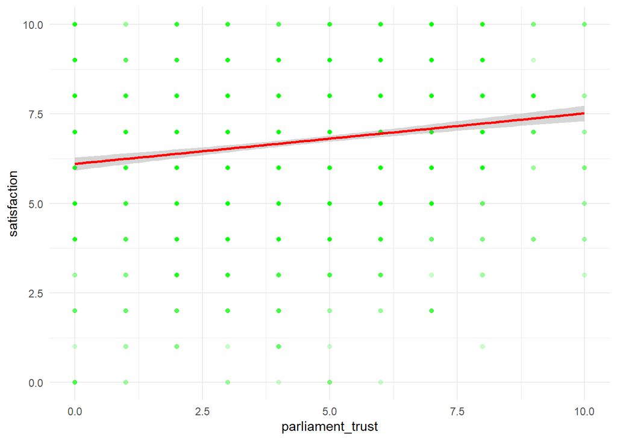

```r
ggplot(ess, aes(x = parliament_trust, y = satisfaction)) +
  geom_point(colour = "green", alpha = 0.2) +
  geom_smooth(method = "lm", color = "red") +
  theme_minimal()
```

> Interpretation: The plot shows positive relationship between trust in parliament and life satisfaction. However, the association appears to be weak since the points are quite dispersed indicating that respondents with similar levels of trust in parliament tend to report rather different life satisfaction levels.

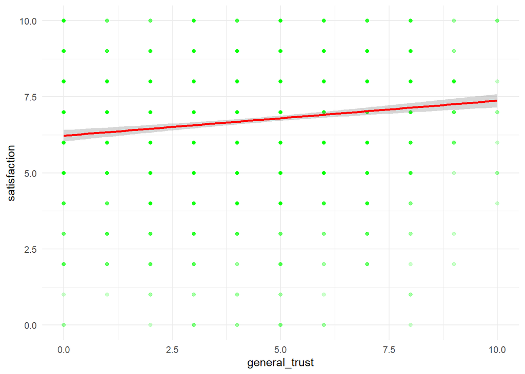

```r
ggplot(ess, aes(x = general_trust, y = satisfaction)) +
  geom_point(colour = "green", alpha = 0.2) +
  geom_smooth(method = "lm", color = "red") +
  theme_minimal()
```

> Interpretation: The plot shows positive relationship between social trust and life satisfaction. However, the situation is simillar to the previous visualization - association appears to be weak since the points are dispersed, which means that respondents with similar levels of social trust tend to report rather different life satisfaction levels.

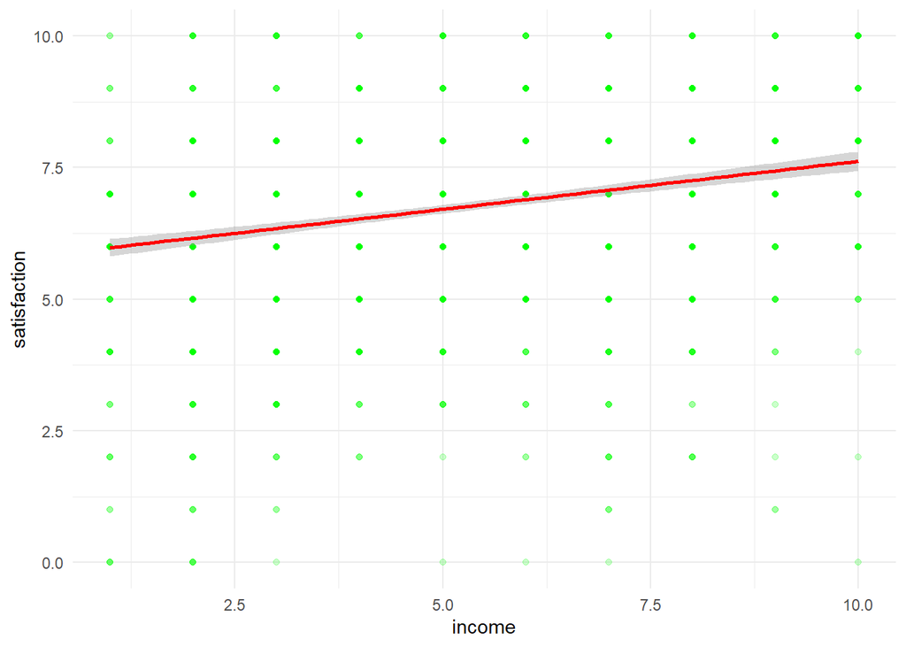

```r
ggplot(ess, aes(x = income, y = satisfaction)) +
  geom_point(colour = "green", alpha = 0.2) +
  geom_smooth(method = "lm", color = "red") +
  theme_minimal()
```

> Interpretation: The plot shows positive relationship between income and life satisfaction. Although trend line has positive slope, association does not seem to be strong - respondents with similar incomes reported varying life satisfaction levels.

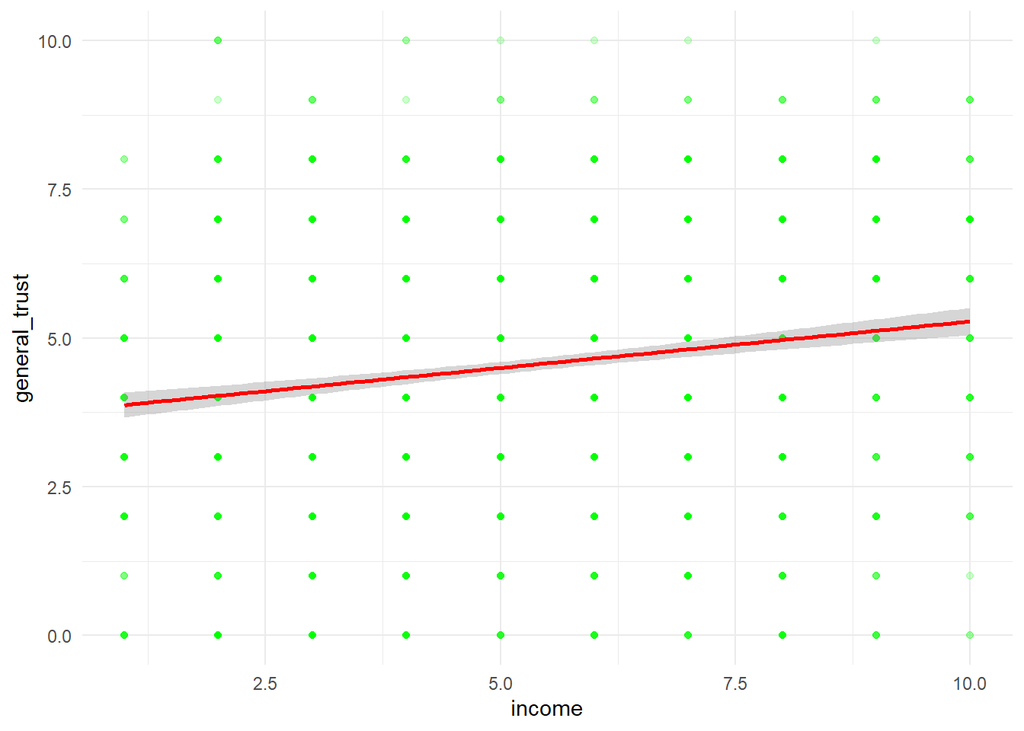

```r
ggplot(ess, aes(x = income, y = general_trust)) +
  geom_point(colour = "green", alpha = 0.2) +
  geom_smooth(method = "lm", color = "red") +
  theme_minimal()
```

> Interpretation: The plot shows weak positive relationship between income and social trust, indicating that although there is a trend that respondents with higher incomes report higher levels of social trust, it is not very pronounced as it can be seen that individuals with similar incomes report a wide range of social trust levels.

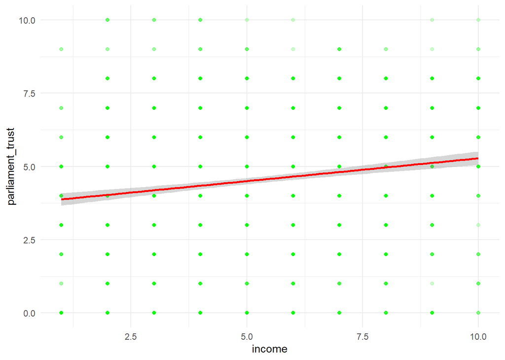

```r
ggplot(ess, aes(x = income, y = parliament_trust)) +
  geom_point(colour = "green", alpha = 0.2) +
  geom_smooth(method = "lm", color = "red") +
  theme_minimal()
```

> Interpretation: The plot shows weak positive relationship between income and trust to parliament. As with the relationship between income and social trust, the trend line indicates positive association between the variables, however, it is clearly visible that the points are quite dispersed.

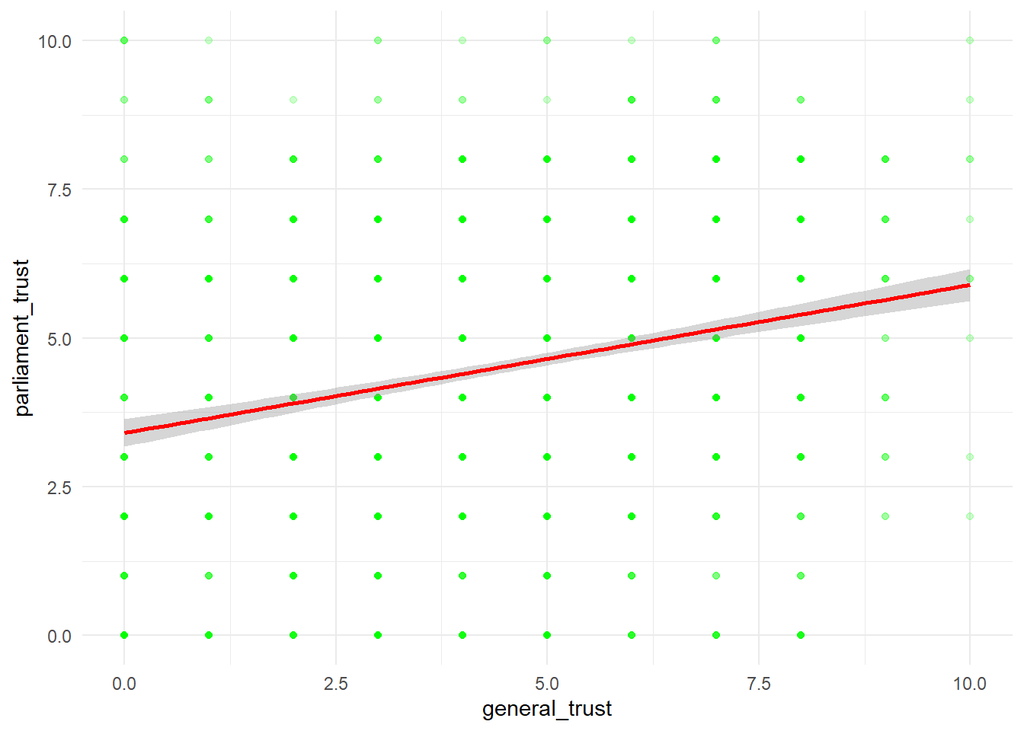

```r
ggplot(ess, aes(x = general_trust, y = parliament_trust)) +
  geom_point(colour = "green", alpha = 0.2) +
  geom_smooth(method = "lm", color = "red") +
  theme_minimal()
```

> Interpretation: The plot shows positive relationship between social trust and trust to parliament Although trend line has a positive slope, association does not seem to be strong - respondents with similar social trust levels have quite different levels of trust to parliament.

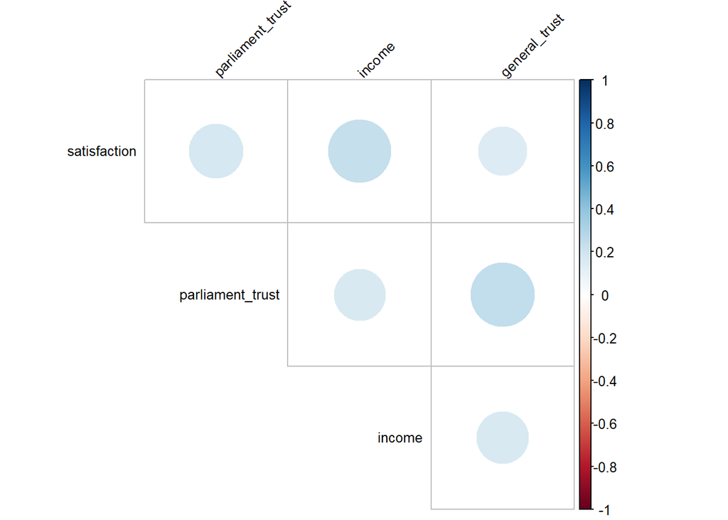

```r
italy_numeric <- ess[, sapply(ess, is.numeric)]

library(corrplot)

cor_matrix <- cor(italy_numeric)

corrplot(cor_matrix,
         method = 'circle',
         type = 'upper',
         tl.col = 'black',
         tl.srt = 45,
         tl.cex = 0.8,
         diag = F)
```

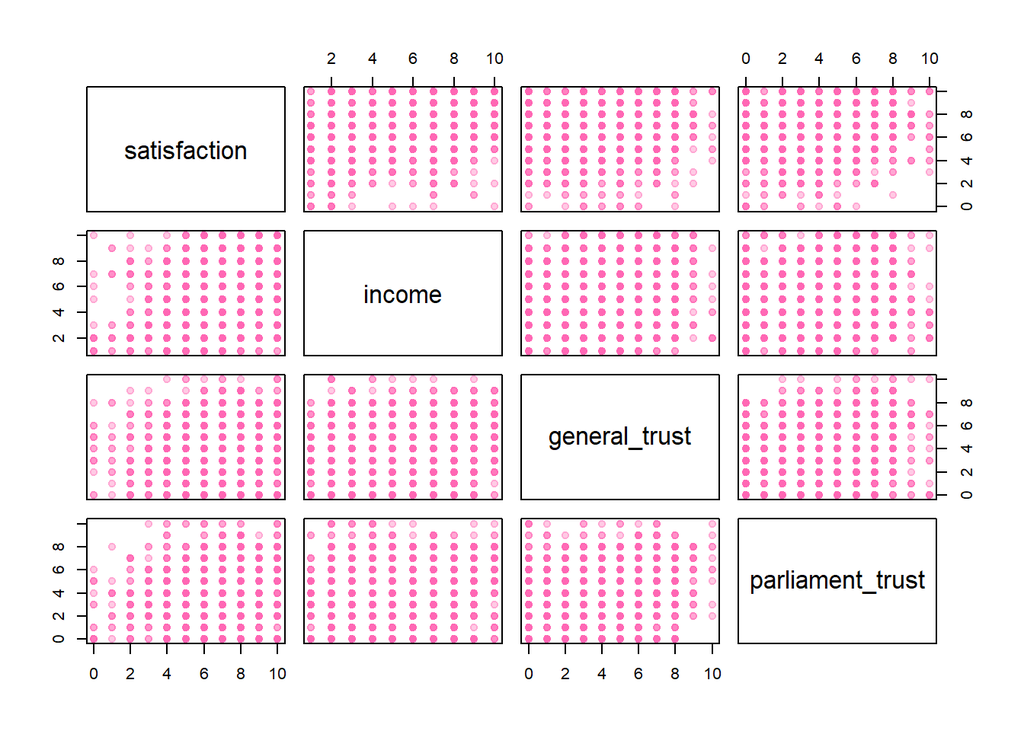

```r
ess_new = ess %>%
  select(satisfaction, income, general_trust, parliament_trust)

pairs(ess_new,
      pch = 19,
      col = rgb(1, 0.4, 0.7, 0.35))
```

> The plots show weak positive correlations between life satisfaction and all 3 predictors (household income, generalized social trust, trust in parliament). It can be noticed that correlations for such pairs of variables as trust in parliament and generalized social trust and life satisfaction and household income are slightly higher than for all other pairs of variables. Taking into account the correlations between all the variables, multicollinearity seems to be unlikely

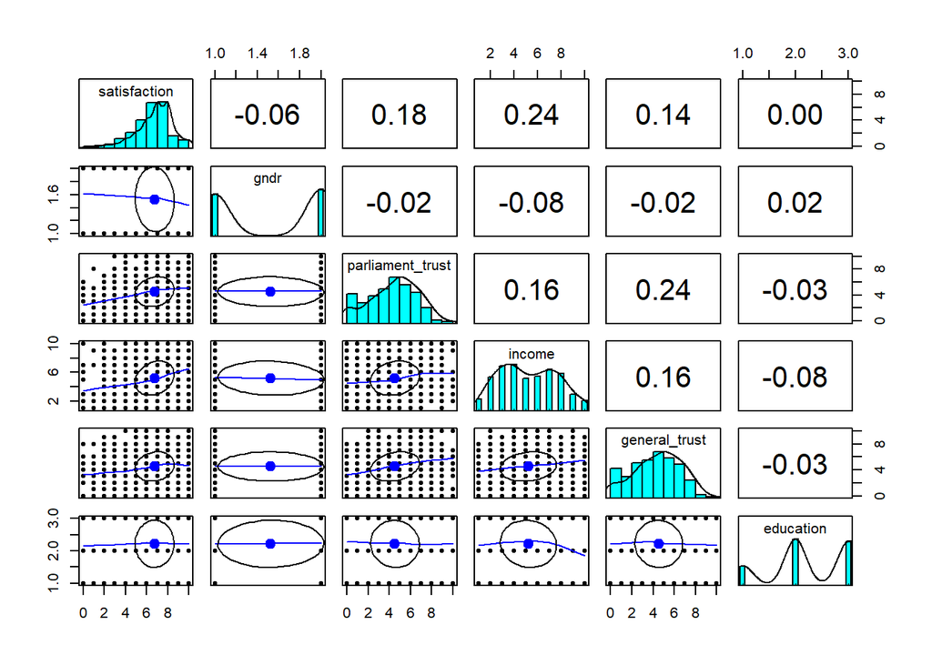

```r
pairs.panels(ess[c("satisfaction", "gndr", "parliament_trust", "income", "general_trust", "education")])
```

> A comprehensively summarizing plot shows variables distributions and their correlation each by each. While parliament and general trust are distributed approx. normally, according to the histograms, satisfaction variable seems skewed to left. No strong correlation is detected between variables.

# Part II

> For this part of the project we start off with the visualisation between categorical variables and the outcome, as scatter plots for the continuous variables were provided above.

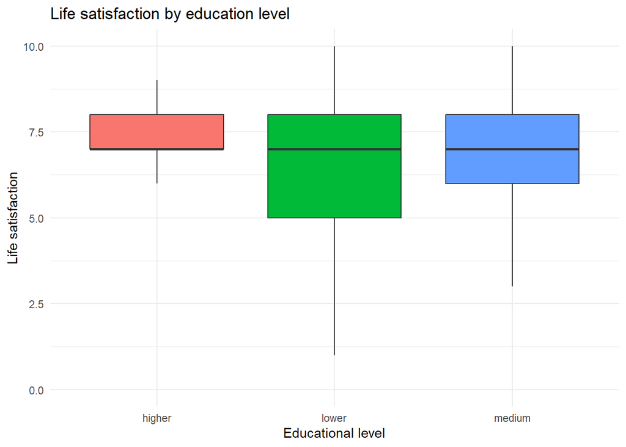

```r
ggplot(ess, aes(x = education, y = satisfaction, fill = education))+
  geom_boxplot(outlier.shape = NA)+
  labs(x = "Educational level", y = "Life satisfaction", title = "Life satisfaction by education level")+
  theme_minimal()+
  theme(legend.position = "none")
```

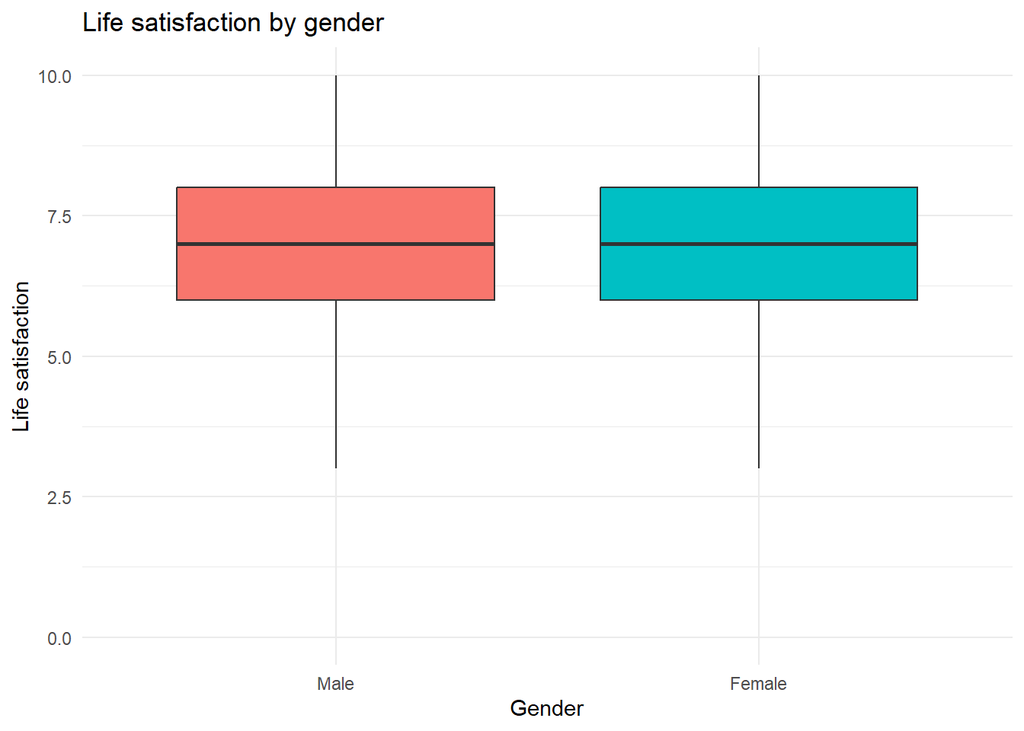

```r
ggplot(ess, aes(x = gndr, y = satisfaction, fill = gndr)) +
  geom_boxplot(outlier.shape = NA) +
  labs(x = "Gender", y = "Life satisfaction", title = "Life satisfaction by gender")+
  theme_minimal()+
  theme(legend.position = "none")
```

> The box plots showed that median life satisfaction scores for each education group is similar (= 7), but variance between them varies. Lower education group shows the highest variance of values, while the higher group shows the lowest. Both gender, though, show very similar variance for life satisfaction scores (median = 7).

```r
model1 <- lm(satisfaction ~ parliament_trust + general_trust + income, data = ess)
model2 <- lm(satisfaction ~ parliament_trust + general_trust + income + education, data = ess)
model3 <- lm(satisfaction ~ parliament_trust + general_trust + income + education + gndr, data = ess)
model4 <- lm(satisfaction ~ parliament_trust + general_trust + income * gndr + education, data = ess)
```

> At this point we built 3 nested additive models, gradually adding predictors, and included 4th model with interaction between income and gender to see whether the interaction adds substantially more explanation of variance.

```r
models <- list(model1, model2, model3, model4)
results <- lapply(models, check_heteroscedasticity)
results_2 <- lapply(models, check_collinearity)
results
```

```
## [[1]]
## Warning: Heteroscedasticity (non-constant error variance) detected (p < .001).
##
## [[2]]
## Warning: Heteroscedasticity (non-constant error variance) detected (p < .001).
##
## [[3]]
## Warning: Heteroscedasticity (non-constant error variance) detected (p < .001).
##
## [[4]]
## Warning: Heteroscedasticity (non-constant error variance) detected (p < .001).
```

```r
results_2
```

```
## [[1]]
## # Check for Multicollinearity
##
## Low Correlation
##
##              Term  VIF   VIF 95% CI adj. VIF Tolerance Tolerance 95% CI
##  parliament_trust 1.08 [1.04, 1.16]     1.04      0.93     [0.87, 0.96]
##     general_trust 1.08 [1.04, 1.16]     1.04      0.92     [0.86, 0.96]
##            income 1.04 [1.01, 1.14]     1.02      0.96     [0.88, 0.99]
##
## [[2]]
## # Check for Multicollinearity
##
## Low Correlation
##
##              Term  VIF   VIF 95% CI adj. VIF Tolerance Tolerance 95% CI
##  parliament_trust 1.08 [1.04, 1.16]     1.04      0.92     [0.86, 0.96]
##     general_trust 1.09 [1.05, 1.16]     1.04      0.92     [0.86, 0.96]
##            income 1.18 [1.13, 1.26]     1.09      0.85     [0.80, 0.88]
##         education 1.16 [1.11, 1.23]     1.04      0.86     [0.81, 0.90]
##
## [[3]]
## # Check for Multicollinearity
##
## Low Correlation
##
##              Term  VIF   VIF 95% CI adj. VIF Tolerance Tolerance 95% CI
##  parliament_trust 1.08 [1.04, 1.16]     1.04      0.92     [0.86, 0.96]
##     general_trust 1.09 [1.05, 1.16]     1.04      0.92     [0.86, 0.96]
##            income 1.19 [1.14, 1.26]     1.09      0.84     [0.79, 0.88]
##         education 1.16 [1.11, 1.23]     1.04      0.86     [0.81, 0.90]
##              gndr 1.01 [1.00, 4.63]     1.00      0.99     [0.22, 1.00]
##
## [[4]]
## # Check for Multicollinearity
##
## Low Correlation
##
##              Term  VIF   VIF 95% CI adj. VIF Tolerance Tolerance 95% CI
##  parliament_trust 1.08 [1.04, 1.16]     1.04      0.92     [0.86, 0.96]
##     general_trust 1.09 [1.05, 1.16]     1.04      0.92     [0.86, 0.96]
##            income 2.39 [2.23, 2.57]     1.55      0.42     [0.39, 0.45]
##         education 1.16 [1.11, 1.24]     1.04      0.86     [0.81, 0.90]
##
## Moderate Correlation
##
##         Term  VIF   VIF 95% CI adj. VIF Tolerance Tolerance 95% CI
##         gndr 5.85 [5.39, 6.36]     2.42      0.17     [0.16, 0.19]
##  income:gndr 6.62 [6.09, 7.21]     2.57      0.15     [0.14, 0.16]
```

> We additionally checked models for heteroscedasticity and collinearity. The results detected heteroscedasticity in all models (at p-level < .001), yet all models (except for the 4th one with the interaction) showed low correlation. To address the issue of heteroscedasticity, later in sjPlot output we specify hierarchical clusteering (HC3) argument to receive more accurate p-values and confidense intervals.

```r
anova(model1, model2, model3, model4)
```

```
## Analysis of Variance Table
##
## Model 1: satisfaction ~ parliament_trust + general_trust + income
## Model 2: satisfaction ~ parliament_trust + general_trust + income + education
## Model 3: satisfaction ~ parliament_trust + general_trust + income + education +
##     gndr
## Model 4: satisfaction ~ parliament_trust + general_trust + income * gndr +
##     education
##   Res.Df    RSS Df Sum of Sq       F    Pr(>F)
## 1   1830 5736.9
## 2   1828 5648.4  2    88.479 14.3248 6.716e-07 ***
## 3   1827 5640.7  1     7.729  2.5025    0.1138
## 4   1826 5639.3  1     1.446  0.4681    0.4940
## ---
## Signif. codes:  0 '***' 0.001 '**' 0.01 '*' 0.05 '.' 0.1 ' ' 1
```

```r
compare_performance(model1, model2, model3, model4, rank = T)
```

```
## # Comparison of Model Performance Indices
##
## Name   | Model |    R2 | R2 (adj.) |  RMSE | Sigma | AIC weights | AICc weights
## -------------------------------------------------------------------------------
## model2 |    lm | 0.095 |     0.093 | 1.755 | 1.758 |       0.346 |        0.348
## model3 |    lm | 0.097 |     0.094 | 1.754 | 1.757 |       0.446 |        0.446
## model4 |    lm | 0.097 |     0.093 | 1.754 | 1.757 |       0.208 |        0.206
## model1 |    lm | 0.081 |     0.080 | 1.769 | 1.771 |    1.65e-06 |     1.69e-06
##
## Name   | BIC weights | Performance-Score
## ----------------------------------------
## model2 |       0.921 |            89.44%
## model3 |       0.075 |            86.45%
## model4 |       0.002 |            69.85%
## model1 |       0.001 |             0.00%
```

```r
summary(model2)
```

```
##
## Call:
## lm(formula = satisfaction ~ parliament_trust + general_trust +
##     income + education, data = ess)
##
## Residuals:
##     Min      1Q  Median      3Q     Max
## -7.1303 -0.8746  0.2451  1.0894  4.7496
##
## Coefficients:
##                  Estimate Std. Error t value Pr(>|t|)
## (Intercept)       5.63730    0.18356  30.711  < 2e-16 ***
## parliament_trust  0.09612    0.01845   5.209 2.11e-07 ***
## general_trust     0.05703    0.01882   3.030  0.00248 **
## income            0.12577    0.01868   6.733 2.22e-11 ***
## educationlower   -0.51263    0.12402  -4.133 3.74e-05 ***
## educationmedium  -0.05870    0.11861  -0.495  0.62072
## ---
## Signif. codes:  0 '***' 0.001 '**' 0.01 '*' 0.05 '.' 0.1 ' ' 1
##
## Residual standard error: 1.758 on 1828 degrees of freedom
## Multiple R-squared:  0.09547,    Adjusted R-squared:  0.093
## F-statistic: 38.59 on 5 and 1828 DF,  p-value: < 2.2e-16
```

> Medium education was not significant (p = .621) and is omitted from the equation

> **Standardized equation: satisfaction** = 0.16 * income + 0.07 * general_trust + 0.12 * parliament_trust - 0.28 * education[Lower]

> The model **explained 9.5% of the variance** (R2 = 0.095, F = 38.59, p < .001).

```r
sjPlot::tab_model(model2,
                  vcov.fun = "HC3",
                  show.est = T,
                  show.stat = T,
                  show.p = T,
                  show.intercept = T,
                  show.aic = T,
                  show.std = T,
                  p.style = "stars")
```

satisfaction

Predictors

Estimates

std. Beta

CI

standardized CI

Statistic

(Intercept)

5.64 ***

0.13

5.25 – 6.03

0.03 – 0.23

28.27

parliament trust

0.10 ***

0.12

0.06 – 0.14

0.07 – 0.17

4.66

general trust

0.06 **

0.07

0.02 – 0.10

0.02 – 0.12

2.76

income

0.13 ***

0.16

0.09 – 0.17

0.11 – 0.21

6.27

education [lower]

-0.51 ***

-0.28

-0.75 – -0.28

-0.40 – -0.15

-4.31

education [medium]

-0.06

-0.03

-0.27 – 0.16

-0.15 – 0.08

-0.54

Observations

1834

R<sup>2</sup> / R<sup>2</sup> adjusted

0.095 / 0.093

AIC

7281.696

- p<0.05 ** p<0.01 *** p<0.001

# Conclusion

> This project examined the associations between life satisfaction and three key predictors: household income, generalized trust and trust in parliament, using data from the European Social Survey (ESS Round 11) for Italy (N = 1,834). Addressing previous research (Clench-Aas & Holte, 2021; Bi et al., 2025), we hypothesized positive correlations between each predictor and life satisfaction, as well as positive intercorrelations among the predictors themselves.

> All six hypotheses were supported, although the strength of associations turned out to be relatively weak.

> Proceeding with the main model, we compared several nested models for linear regression and compared their performance. The best model fit included the following predictors: **income (by deciles), general_trust, parliament_trust and education (by categories).**

> The model **explained 9.5% of the variance** in life satisfaction (R2 = 0.095, F = 38.59, p < .001). Though R2 appears to be small, we suppose that a concept of life satisfaction is too complex to be fully predicted by the specified predictors, so more in-depth, multi-factor analysis is required.

> Parliament and generalized trust, income and contrast between lower and higher education showed significant results, with education being the most powerful predictor in the model (est. Beta = -0.28). Medium education vs. higher education showed no significant difference (est. Beta = -0.03, p = .62). Gender **did not improve** model fit (F-test between model2 and model3: p > .05) and was remowed from the final model. Income × gender **interaction was also not significant** (model4).

> The **key result** is that income, generalized trust and parliament trust are each positively associated with life satisfaction in Italy, with lower education (but not medium education) showing a meaningful negative effect.

> For future research, it is better to include more predictors to achieve higher variance explanation and increase power of the model, as well as address the issue of causal direction between life satisfaction and trust, where each variable can affect each other.